# Reading, Writing, and Manipulating Data in R

# Base Functions Common in Data Analysis

Here are some functions from the *base* package commommly used in analysis (from *R for Beginners* pg. 36):

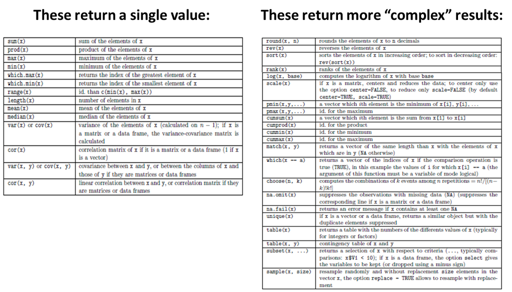

# The Power of Packages

The power of R, and open source software in general, is the ability to use code written by other users for specific tasks (as well as to contribute code you might have written for yourself to accomplish something). These compilations of code are referred to as **packages**, and there are more than 9,000 of them available for download.

There are many places to research packages and figure out which ones are the best for the task at hand, but one of the best places to start is the [CRAN Task Views](https://cran.r-project.org/web/views/) webpage. This webpage groups packages into common “tasks”, which makes it a lot easier to understand and compare “families” of packages.

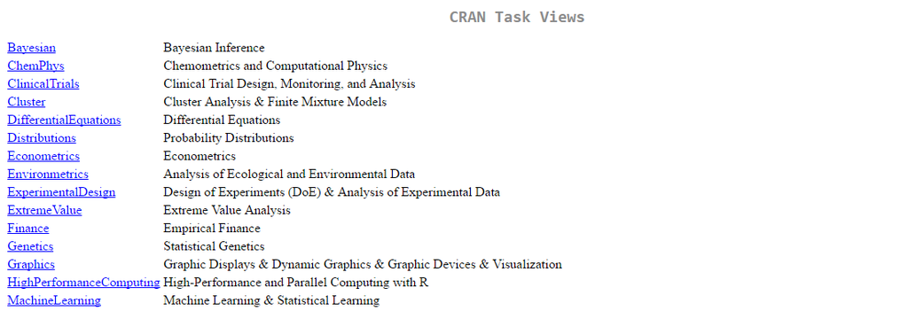

*Fig 2.3: Some Examples of CRAN Task Views*

# Installing, Loading, and Maintaining Packages

- **install.pacakges()**: downloads the source code for packages
- **library()**: loads the package into the current session (so you can use it!)
- **require()**:loads a package into the current session, returning FALSE if the package does not exist. Designed to be used inside other functions

```r
# command to install a specific package/vector of package names
install.packages("package")

# once package(s) is downloaded, load it into your working session
library("package")
```

- **package_version()**: return the version of the specific package(s)
- **update.packages()**: compares the package versions on your machine against the newest version available on the repository, and downloads any updates
- **packageStatus()**: outputs a summary on the status of installed packages on your machine, as well as information on packages available at various repositories
  - There are other repositories offering R pacakges besides CRAN (e.g. **R-Forge**)

# Try it!: Installing and Loading Packages

Install and load the following packages (if you don’t have them installed already):

- readr
- tidyr
- dplyr
- stringr

# Introduction to the Tidyverse

The tidyverse packages we will use today include:

- **readr** for data importing
- **tidyr** for reshaping “messy” data
- **stringr** for working with character strings
- **dplyr** for data manipulation

Each of these packages are built with the intention of being used on **tidy** datasets, a familiar concept defining a useful format for structuring data.

For more information regarding the **tidyverse** packages, check out the [Tidyverse GitHub Page](https://github.com/tidyverse/tidyverse).

# Reading Data with readr

The readr package is used to read data from flat files into R quickly and efficiently. Conveniently, the arguments remain the same (give or take a few) across all of the functions:

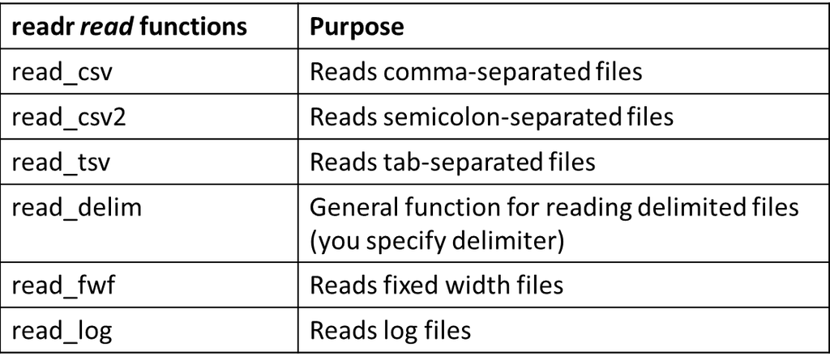

*Fig 2.4: Data Import Functions from readr*

**NOTE** that **read_csv()**, **read_csv2()**, and **read_tsv()** are all special cases of **read_delim()**.

# Try it!: Return arguments for readr read functions

What do you anticipate the resuts to be of the two functions below?

```r
args(read_delim)
args(read_csv)
```

# Arguments to readr Read Functions

A complete list of arguments to *readr* functions can be found in the [readr documentation](https://cran.r-project.org/web/packages/readr/readr.pdf). The mostly commonly used are:

- **file**: specify the path to the file for import
- **delim**: used to specify the field delimeter when using read_delim.
  - For read_csv(), read_csv2(), and read_tsv() the delimeters are already specified within the function call.
- **col_names**: set the column names for each field. The default *TRUE* expects a header row, and *FALSE* will auto-generate column names (X1, …, Xn).
  - You can also provide a character vector of column names that will be used for column names.
- **col_types**: useful for specifying the columns types (modes). If *NULL* then the data type will be inferred from the first 1000 rows of the input.
  - To specify the data type of each column, use the **cols()** argument and one of the following abbreviations: **c** = character, **i** = integer, **n** = number, **d** double, **l** = logical, **D** = date, **T** = date time, **t** = time, **-** = skip.
- **na**: tell R which character strings to use for missing values.
- **skip**: how many lines to skip before reading data
- **n_max**: the maximum number of lines to import

# Tryit!: Read Hurricane Data

Using the **read_csv()** function, read in the file “3_data_hurricane.csv”.

If you receive an error that the file does not exist, be sure to check/set your working directory!

# Tryit!: Read Hurricane Data

```r
# read file using default behavior
hrcn <- read_csv("3_data_hurricane_small.csv")
head(hrcn)

#
hrcn<- read_csv("3_data_hurricane_small.csv",
                    col_names = c("id", "name", "month", "day", "hour", "year", "lat", "lon",
                                  paste("radius_34", c("ne", "se", "sw", "nw"), sep = "_"),
                                  paste("radius_50", c("ne", "se", "sw", "nw"), sep = "_"),
                                  paste("radius_64", c("ne", "se", "sw", "nw"), sep = "_")),
                col_types = "ccnnnnnnnnnnnnnnnnnn", skip = 1)

head(hrcn)
```